# 1 ANN MNIST Image Classification

```python
# ANN for MNIST Image Classification using tensorflow

import tensorflow as tf
print(tf.__version__)
```

```
2.19.0
```

```python
# https://www.researchgate.net/publication/330902210/figure/fig1/AS:878026619375622@1586349267376/mage-of-Abraham-Lincoln-as-a-matrix-of-pixel-values.ppm

# https://corochann.com/wp-content/uploads/2021/09/mnist_plot.png

# https://www.researchgate.net/profile/Soha-Boroojerdi/publication/361444345/figure/fig1/AS:11431281091155908@1666326170916/Representation-of-value-three-in-the-MNIST-dataset-and-its-equivalent-matrix.ppm
```

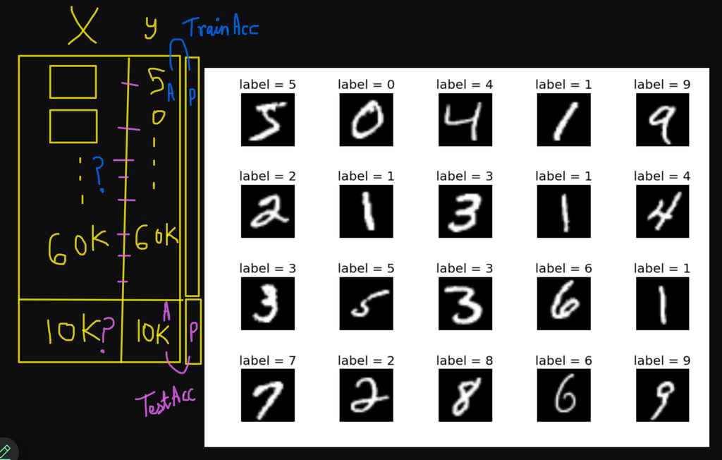

### 📝 Problem Statement: Handwritten Digit Recognition Using Deep Learning on MNIST Dataset

#### **Objective:**

To develop and evaluate a deep learning model that can accurately classify handwritten digits (0–9) from grayscale images using the MNIST dataset. The goal is to achieve high accuracy and generalization ability on unseen digit images.

#### **Background:**

Handwritten digit recognition is a foundational task in the field of computer vision and machine learning. The MNIST dataset is a benchmark dataset consisting of 70,000 28x28 pixel grayscale images of handwritten digits — 60,000 for training and 10,000 for testing. Each image is labeled with the correct digit (0 to 9).

Deep learning, especially Convolutional Neural Networks (CNNs), has proven to be highly effective in image classification tasks. By applying deep learning techniques to the MNIST dataset, we aim to learn a robust model capable of recognizing handwritten digits with minimal pre-processing.

#### **Dataset Description:**

- **Name:** MNIST (Modified National Institute of Standards and Technology) Dataset
- **Format:** 28x28 grayscale images
- **Training Samples:** 60,000
- **Test Samples:** 10,000
- **Classes:** 10 (Digits 0 through 9)

#### **Tasks:**

1. Load and preprocess the MNIST dataset.
2. Design and implement a neural network (fully connected or CNN).
3. Train the model on the training data.
4. Evaluate the model on the test data.
5. Tune hyperparameters (learning rate, number of layers, dropout, etc.) to improve performance.
6. Visualize model performance using accuracy/loss plots and confusion matrix.
7. (Optional) Test the model on custom handwritten digits.

#### **Success Criteria:**

- Achieve at least 98% accuracy on the MNIST test set.
- Demonstrate generalization with minimal overfitting.
- Clear visualization of results and performance metrics.

#### **Tools and Libraries:**

- Python
- TensorFlow or PyTorch
- NumPy, Matplotlib, and Seaborn for visualization

```python
# Load the MNIST dataset
mnist = tf.keras.datasets.mnist
print(mnist)
```

```
<module 'keras.datasets.mnist' from '/opt/anaconda3/lib/python3.11/site-packages/keras/datasets/mnist/__init__.py'>
```

```python
print(type(mnist))
```

```
<class 'module'>
```

```python
(x_train, y_train), (x_test, y_test) = mnist.load_data()

# Print the shape of the x_train, y_train, x_test, y_test
print("x_train shape:", x_train.shape)
print("y_train shape:", y_train.shape)
print("x_test shape:", x_test.shape)
print("y_test shape:", y_test.shape)
```

```
x_train shape: (60000, 28, 28)
y_train shape: (60000,)
x_test shape: (10000, 28, 28)
y_test shape: (10000,)
```

```python
x_train[0].shape
```

```
(28, 28)
```

```python
# x_train[0]
y_train[0]
```

```
5
```

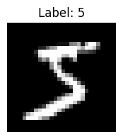

```python
# Plot the 0th image of x_train
import matplotlib.pyplot as plt

plt.figure(figsize=(2,2))
plt.imshow(x_train[0], cmap='gray')
# What is imshow()?
# imshow() is a function in the matplotlib library that is used to display images. It takes a 2D array (for grayscale images) or a 3D array (for RGB images) as input and renders it as an image.
# The function automatically scales the pixel values to fit within the display range, which is typically 0 to 255 for 8-bit images. You can also specify a colormap to change the way the image is displayed.
# In this case, since x_train[0] is a 2D array representing a grayscale image, imshow() will display it as a grayscale image.

plt.title("Label: {}".format(y_train[0]))
plt.axis('off')
plt.show()
```

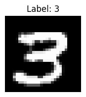

```python
# Plot the 111th image of x_train
import matplotlib.pyplot as plt

plt.figure(figsize=(2,2))
plt.imshow(x_train[111], cmap='gray')
plt.title("Label: {}".format(y_train[111]))
plt.axis('off')
plt.show()
```

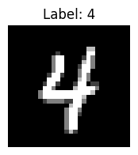

```python
# Plot the 53450th image of x_train
import matplotlib.pyplot as plt

plt.figure(figsize=(2,2))
plt.imshow(x_train[53450], cmap='gray')
plt.title("Label: {}".format(y_train[53450]))
plt.axis('off')
plt.show()
```

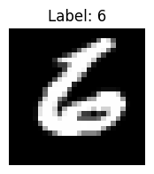

```python
# Plot the 9999th image of x_test
import matplotlib.pyplot as plt

plt.figure(figsize=(2,2))
plt.imshow(x_test[9999], cmap='gray')
plt.title("Label: {}".format(y_test[9999]))
plt.axis('off')
plt.show()
```

```python
# Now, lets normalize the images to have pixel values between 0 and 1 instead of 0 to 255. This will help the model to converge faster.
# What Normalization Does
# Normalization rescales the pixel values of the images to a standard range, typically [0, 1]. This is important for neural networks because:
# 1. Faster Convergence: Normalized inputs help the model to converge faster during training.
# 2. Improved Stability: It reduces the risk of getting stuck in local minima.
# 3. Better Performance: Models tend to perform better when the input features are on a similar scale.

x_train = x_train / 255.0
x_test = x_test / 255.0
```

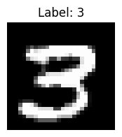

```python
# Plot the 111th image of x_train
import matplotlib.pyplot as plt

plt.figure(figsize=(2,2))
plt.imshow(x_train[111], cmap='gray')
plt.title("Label: {}".format(y_train[111]))
plt.axis('off')
plt.show()
```

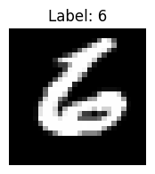

```python
# Plot the 9999th image of x_test
import matplotlib.pyplot as plt

plt.figure(figsize=(2,2))
plt.imshow(x_test[9999], cmap='gray')
plt.title("Label: {}".format(y_test[9999]))
plt.axis('off')
plt.show()
```

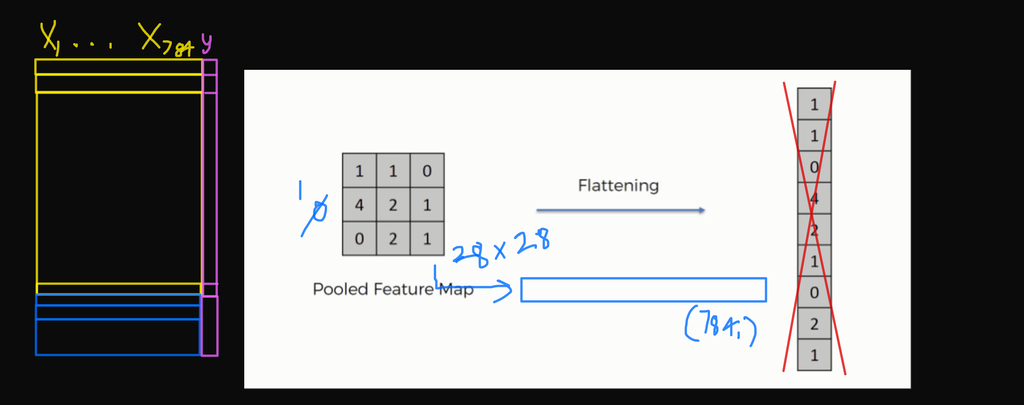

```python
print(x_train.shape)
print((x_train.reshape(60000, 28*28)).shape)
```

```
(60000, 28, 28)
(60000, 784)
```

```python
# Lets continue building the ML model using the DecisionTreeClassifier

from sklearn.tree import DecisionTreeClassifier
from sklearn.metrics import accuracy_score, classification_report, confusion_matrix
dtc = DecisionTreeClassifier(max_depth=10, random_state=42)
dtc.fit(x_train.reshape(60000, 28*28), y_train)
y_pred_train = dtc.predict(x_train.reshape(60000, 28*28))
y_pred_test = dtc.predict(x_test.reshape(10000, 28*28))
# Print the accuracy score for train and test
print("Train Accuracy:", accuracy_score(y_train, y_pred_train))
print("Test Accuracy:", accuracy_score(y_test, y_pred_test))
```

```
Train Accuracy: 0.8995166666666666
Test Accuracy: 0.8663
```

```python
# Lets continue building the ML model using the SVC

from sklearn.svm import SVC
from sklearn.metrics import accuracy_score, classification_report, confusion_matrix
svc = SVC(kernel='linear', random_state=42)
svc.fit(x_train.reshape(60000, 28*28), y_train)
y_pred_train = svc.predict(x_train.reshape(60000, 28*28))
y_pred_test = svc.predict(x_test.reshape(10000, 28*28))
# Print the accuracy score for train and test
print("Train Accuracy:", accuracy_score(y_train, y_pred_train))
print("Test Accuracy:", accuracy_score(y_test, y_pred_test))
```

```
Train Accuracy: 0.97075
Test Accuracy: 0.9404
```

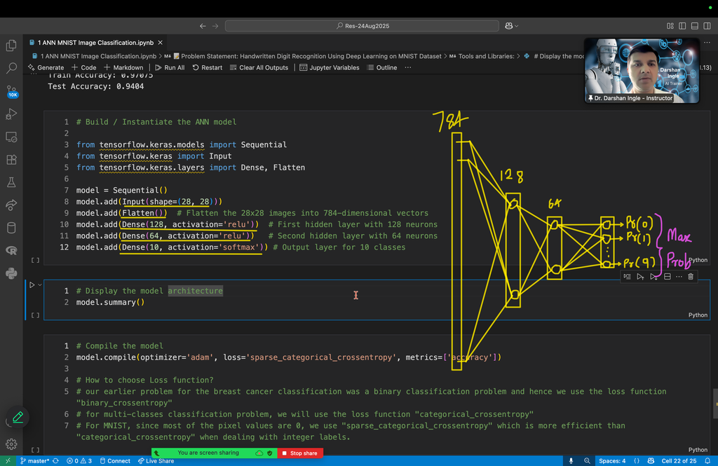

```python
# Build / Instantiate the ANN model

from tensorflow.keras.models import Sequential
from tensorflow.keras import Input
from tensorflow.keras.layers import Dense, Flatten

model = Sequential()
model.add(Input(shape=(28, 28)))
model.add(Flatten())  # Flatten the 28x28 images into 784-dimensional vectors
model.add(Dense(128, activation='relu'))  # First hidden layer with 128 neurons
model.add(Dense(64, activation='relu'))   # Second hidden layer with 64 neurons
model.add(Dense(10, activation='softmax')) # Output layer for 10 classes
```

```python
# Compile the model
model.compile(optimizer='adam', loss='sparse_categorical_crossentropy', metrics=['accuracy'])

# How to choose Loss function?
# our earlier problem for the breast cancer classification was a binary classification problem and hence we use the loss function "binary_crossentropy"
# for multi-classes classification problem, we will use the loss function "categorical_crossentropy"
# For MNIST, since most of the pixel values are 0, we use "sparse_categorical_crossentropy" which is more efficient than "categorical_crossentropy" when dealing with integer labels.
```

```python
# Display the model architecture
model.summary()
```

```
Model: "sequential"
```

```
┏━━━━━━━━━━━━━━━━━━━━━━━━━━━━━━━━━┳━━━━━━━━━━━━━━━━━━━━━━━━┳━━━━━━━━━━━━━━━┓
┃ Layer (type)                    ┃ Output Shape           ┃       Param # ┃
┡━━━━━━━━━━━━━━━━━━━━━━━━━━━━━━━━━╇━━━━━━━━━━━━━━━━━━━━━━━━╇━━━━━━━━━━━━━━━┩
│ flatten (Flatten)               │ (None, 784)            │             0 │
├─────────────────────────────────┼────────────────────────┼───────────────┤
│ dense (Dense)                   │ (None, 128)            │       100,480 │
├─────────────────────────────────┼────────────────────────┼───────────────┤
│ dense_1 (Dense)                 │ (None, 64)             │         8,256 │
├─────────────────────────────────┼────────────────────────┼───────────────┤
│ dense_2 (Dense)                 │ (None, 10)             │           650 │
└─────────────────────────────────┴────────────────────────┴───────────────┘
```

```
 Total params: 109,386 (427.29 KB)
```

```
 Trainable params: 109,386 (427.29 KB)
```

```
 Non-trainable params: 0 (0.00 B)
```

```python
# Train the model
r = model.fit(x_train, y_train, validation_data=(x_test, y_test), epochs=15, batch_size=64)
```

```
938/938 ━━━━━━━━━━━━━━━━━━━━ 2s 1ms/step - accuracy: 0.8606 - loss: 0.4935 - val_accuracy: 0.9569 - val_loss: 0.1484
938/938 ━━━━━━━━━━━━━━━━━━━━ 1s 1ms/step - accuracy: 0.9633 - loss: 0.1218 - val_accuracy: 0.9699 - val_loss: 0.0988
938/938 ━━━━━━━━━━━━━━━━━━━━ 1s 1ms/step - accuracy: 0.9767 - loss: 0.0782 - val_accuracy: 0.9737 - val_loss: 0.0833
938/938 ━━━━━━━━━━━━━━━━━━━━ 1s 1ms/step - accuracy: 0.9822 - loss: 0.0550 - val_accuracy: 0.9756 - val_loss: 0.0816
938/938 ━━━━━━━━━━━━━━━━━━━━ 1s 1ms/step - accuracy: 0.9861 - loss: 0.0429 - val_accuracy: 0.9775 - val_loss: 0.0762
938/938 ━━━━━━━━━━━━━━━━━━━━ 1s 1ms/step - accuracy: 0.9887 - loss: 0.0342 - val_accuracy: 0.9786 - val_loss: 0.0755
938/938 ━━━━━━━━━━━━━━━━━━━━ 1s 1ms/step - accuracy: 0.9904 - loss: 0.0281 - val_accuracy: 0.9764 - val_loss: 0.0827
938/938 ━━━━━━━━━━━━━━━━━━━━ 1s 1ms/step - accuracy: 0.9927 - loss: 0.0218 - val_accuracy: 0.9792 - val_loss: 0.0829
938/938 ━━━━━━━━━━━━━━━━━━━━ 1s 1ms/step - accuracy: 0.9931 - loss: 0.0198 - val_accuracy: 0.9730 - val_loss: 0.0993
938/938 ━━━━━━━━━━━━━━━━━━━━ 1s 1ms/step - accuracy: 0.9945 - loss: 0.0165 - val_accuracy: 0.9763 - val_loss: 0.0917
938/938 ━━━━━━━━━━━━━━━━━━━━ 1s 1ms/step - accuracy: 0.9964 - loss: 0.0115 - val_accuracy: 0.9744 - val_loss: 0.1045
938/938 ━━━━━━━━━━━━━━━━━━━━ 1s 1ms/step - accuracy: 0.9953 - loss: 0.0136 - val_accuracy: 0.9789 - val_loss: 0.0917
938/938 ━━━━━━━━━━━━━━━━━━━━ 1s 1ms/step - accuracy: 0.9965 - loss: 0.0108 - val_accuracy: 0.9805 - val_loss: 0.0905
938/938 ━━━━━━━━━━━━━━━━━━━━ 1s 938us/step - accuracy: 0.9973 - loss: 0.0092 - val_accuracy: 0.9788 - val_loss: 0.0937
938/938 ━━━━━━━━━━━━━━━━━━━━ 1s 874us/step - accuracy: 0.9968 - loss: 0.0094 - val_accuracy: 0.9775 - val_loss: 0.1004
```

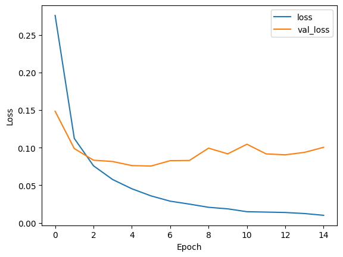

```python
# Plot the loss and val_loss
import matplotlib.pyplot as plt

plt.plot(r.history['loss'], label='loss')
plt.plot(r.history['val_loss'], label='val_loss')
plt.xlabel('Epoch')
plt.ylabel('Loss')
plt.legend()
plt.show()
```

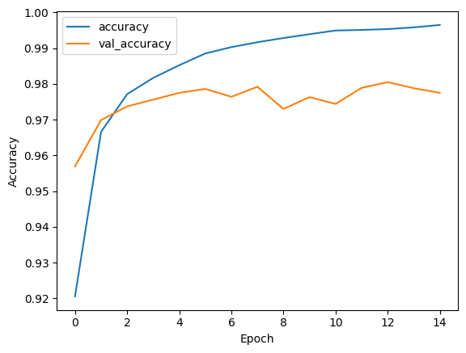

```python
# Plot the accuracy and val_accuracy
import matplotlib.pyplot as plt

plt.plot(r.history['accuracy'], label='accuracy')
plt.plot(r.history['val_accuracy'], label='val_accuracy')
plt.xlabel('Epoch')
plt.ylabel('Accuracy')
plt.legend()
plt.show()
```

```python
# Observation:
# the accuracy is pretty high and the testing accuracy is also stable while the training accuracy still has a scope of increasing.
# with respect to the loss function, we observe that the Training loss has become stable while the testing loss is gradually increasing.
# this means that the model is becoming more and more confident on the training, data set and relatively less confident on the testing data set, and hence the losses in increasing.
# this is an ideal scenario of overfitting, where we see the model is predicting confidently wrong outputs.
```

```python
# Evaluate the model on training dataset
train_loss, train_accuracy = model.evaluate(x_train, y_train, verbose=0)
print(f"Training Loss: {train_loss:.4f}")
print(f"Training Accuracy: {train_accuracy:.4f}")

# Evaluate the model on testing dataset
test_loss, test_accuracy = model.evaluate(x_test, y_test, verbose=0)
print(f"Testing Loss: {test_loss:.4f}")
print(f"Testing Accuracy: {test_accuracy:.4f}")
```

```
Training Loss: 0.0102
Training Accuracy: 0.9964
Testing Loss: 0.1004
Testing Accuracy: 0.9775
```

```python
# Predict on x_test
y_pred = model.predict(x_test)
y_pred.shape
```

```
313/313 ━━━━━━━━━━━━━━━━━━━━ 0s 465us/step
```

```
(10000, 10)
```

```python
# y_pred
print(y_pred[0])

import numpy as np
print(np.sum(y_pred[0]))  # should be 1.0 as they are probabilities
print(np.sum(y_pred[110]))  # should be 1.0 as they are probabilities
```

```
[1.1297749e-12 2.1748996e-09 7.6816242e-09 1.2080332e-11 6.3593910e-17
 1.8208098e-15 3.3336887e-21 1.0000000e+00 3.4381255e-11 1.3948838e-08]
1.0
1.0
```

```python
y_pred = np.argmax(y_pred, axis=1)
# argmax() - returns the indices of the maximum values along an axis
# Syntax: np.argmax(a, axis=None)
# This function is useful when you want to convert the predicted probabilities into class labels by selecting the class with the highest probability.
y_pred.shape
```

```
(10000,)
```

```python
y_pred
```

```
array([7, 2, 1, ..., 4, 5, 6])
```

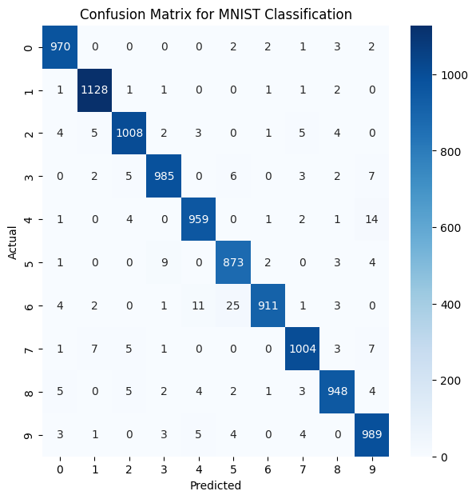

```python
# Plot the confusion matrix

import seaborn as sns
import matplotlib.pyplot as plt

plt.figure(figsize=(7,7))
cm = confusion_matrix(y_test, y_pred)
sns.heatmap(cm, annot=True, fmt='d', cmap='Blues')
plt.xlabel('Predicted')
plt.ylabel('Actual')
plt.title('Confusion Matrix for MNIST Classification')
plt.show()
```

```python
# np.where(y_test != y_pred)
np.where(y_test != y_pred)[0]
```

```
array([ 115,  217,  247,  321,  339,  340,  359,  445,  447,  449,  495,
        508,  552,  582,  625,  659,  691,  720,  877,  947,  951, 1003,
       1014, 1039, 1112, 1156, 1161, 1178, 1182, 1226, 1242, 1247, 1292,
       1319, 1393, 1444, 1522, 1530, 1549, 1587, 1621, 1681, 1717, 1790,
       1800, 1901, 1941, 1955, 1982, 1987, 2023, 2024, 2035, 2047, 2053,
       2070, 2098, 2109, 2118, 2125, 2130, 2135, 2272, 2293, 2299, 2369,
       2408, 2414, 2447, 2462, 2488, 2534, 2560, 2597, 2648, 2654, 2713,
       2743, 2758, 2810, 2860, 2877, 2896, 2921, 2927, 2939, 2953, 2995,
       3060, 3117, 3225, 3342, 3375, 3422, 3451, 3474, 3475, 3503, 3520,
       3549, 3550, 3597, 3718, 3727, 3751, 3762, 3776, 3801, 3808, 3811,
       3818, 3838, 3853, 3893, 3902, 3906, 3951, 3976, 4027, 4063, 4163,
       4193, 4199, 4201, 4207, 4248, 4289, 4294, 4360, 4382, 4425, 4443,
       4497, 4504, 4536, 4571, 4575, 4601, 4619, 4699, 4740, 4798, 4807,
       4814, 4823, 4838, 4860, 4876, 4880, 4943, 4952, 4966, 4989, 5046,
       5140, 5199, 5228, 5265, 5331, 5457, 5600, 5634, 5642, 5676, 5734,
       5887, 5936, 5937, 5955, 5973, 6011, 6023, 6030, 6045, 6059, 6071,
       6166, 6555, 6574, 6577, 6597, 6625, 6632, 6651, 6755, 6783, 6847,
       7179, 7434, 7457, 7823, 7902, 7921, 7928, 8059, 8094, 8183, 8246,
       8311, 8375, 8456, 8527, 9009, 9015, 9024, 9280, 9587, 9634, 9664,
       9669, 9679, 9692, 9698, 9700, 9729, 9745, 9764, 9770, 9782, 9792,
       9793, 9839, 9858, 9904, 9944])
```

```python
# Lets find the indexes of all the misclassified images
misclassified_idx = np.where(y_test != y_pred)[0]
print(misclassified_idx)
print()

# Print the total number of misclassified images
print("Total number of misclassified images:", len(misclassified_idx))
```

```
[ 115  217  247  321  339  340  359  445  447  449  495  508  552  582
  625  659  691  720  877  947  951 1003 1014 1039 1112 1156 1161 1178
 1182 1226 1242 1247 1292 1319 1393 1444 1522 1530 1549 1587 1621 1681
 1717 1790 1800 1901 1941 1955 1982 1987 2023 2024 2035 2047 2053 2070
 2098 2109 2118 2125 2130 2135 2272 2293 2299 2369 2408 2414 2447 2462
 2488 2534 2560 2597 2648 2654 2713 2743 2758 2810 2860 2877 2896 2921
 2927 2939 2953 2995 3060 3117 3225 3342 3375 3422 3451 3474 3475 3503
 3520 3549 3550 3597 3718 3727 3751 3762 3776 3801 3808 3811 3818 3838
 3853 3893 3902 3906 3951 3976 4027 4063 4163 4193 4199 4201 4207 4248
 4289 4294 4360 4382 4425 4443 4497 4504 4536 4571 4575 4601 4619 4699
 4740 4798 4807 4814 4823 4838 4860 4876 4880 4943 4952 4966 4989 5046
 5140 5199 5228 5265 5331 5457 5600 5634 5642 5676 5734 5887 5936 5937
 5955 5973 6011 6023 6030 6045 6059 6071 6166 6555 6574 6577 6597 6625
 6632 6651 6755 6783 6847 7179 7434 7457 7823 7902 7921 7928 8059 8094
 8183 8246 8311 8375 8456 8527 9009 9015 9024 9280 9587 9634 9664 9669
 9679 9692 9698 9700 9729 9745 9764 9770 9782 9792 9793 9839 9858 9904
 9944]

Total number of misclassified images: 225
```

```python
(225/10000) * 100
```

```
2.25
```

```python
100 - 2.25
```

```
97.75
```

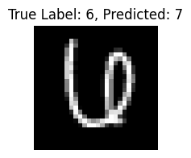

```python
# Plot some random misclassified images
i = np.random.choice(misclassified_idx)

plt.figure(figsize=(2,2))
plt.imshow(x_test[i], cmap='gray')
plt.title("True Label: {}, Predicted: {}".format(y_test[i], y_pred[i]))
plt.axis('off')
plt.show()
```

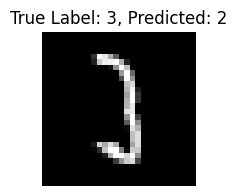

```python
# Plot some random misclassified images
i = np.random.choice(misclassified_idx)

plt.figure(figsize=(2,2))
plt.imshow(x_test[i], cmap='gray')
plt.title("True Label: {}, Predicted: {}".format(y_test[i], y_pred[i]))
plt.axis('off')
plt.show()
```

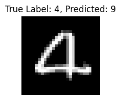

```python
# Plot some random misclassified images
i = np.random.choice(misclassified_idx)

plt.figure(figsize=(2,2))
plt.imshow(x_test[i], cmap='gray')
plt.title("True Label: {}, Predicted: {}".format(y_test[i], y_pred[i]))
plt.axis('off')
plt.show()
```

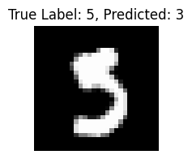

```python
# Plot some random misclassified images
i = np.random.choice(misclassified_idx)

plt.figure(figsize=(2,2))
plt.imshow(x_test[i], cmap='gray')
plt.title("True Label: {}, Predicted: {}".format(y_test[i], y_pred[i]))
plt.axis('off')
plt.show()
```

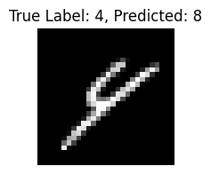

```python
# Plot some random misclassified images
i = np.random.choice(misclassified_idx)

plt.figure(figsize=(2,2))
plt.imshow(x_test[i], cmap='gray')
plt.title("True Label: {}, Predicted: {}".format(y_test[i], y_pred[i]))
plt.axis('off')
plt.show()
```

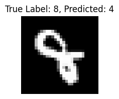

```python
# Plot some random misclassified images
i = np.random.choice(misclassified_idx)

plt.figure(figsize=(2,2))
plt.imshow(x_test[i], cmap='gray')
plt.title("True Label: {}, Predicted: {}".format(y_test[i], y_pred[i]))
plt.axis('off')
plt.show()
```

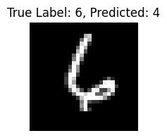

```python
# Plot some random misclassified images
i = np.random.choice(misclassified_idx)

plt.figure(figsize=(2,2))
plt.imshow(x_test[i], cmap='gray')
plt.title("True Label: {}, Predicted: {}".format(y_test[i], y_pred[i]))
plt.axis('off')
plt.show()
```

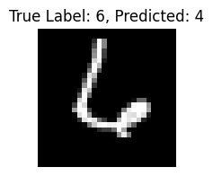

```python
# Plot some random misclassified images
i = np.random.choice(misclassified_idx)

plt.figure(figsize=(2,2))
plt.imshow(x_test[i], cmap='gray')
plt.title("True Label: {}, Predicted: {}".format(y_test[i], y_pred[i]))
plt.axis('off')
plt.show()
```